# Machine Learning: Logistic Regression

2017-06-11

# 1 Logistic Regression

[Logistic Regression](https://en.wikipedia.org/wiki/Logistic_regression) is a regression model in which the response variable is categorical. Instead of trying to predict the numerical value of an outcome variable, we’ll predict the probability that the outcome is in one of two classes. Since this probability will vary between 0 and 1 we need to have a function which saturates at these extremes. There are a variety of functions which will do this for us, but we’ll use the [logistic function](https://en.wikipedia.org/wiki/Logistic_function)
$$P(Y = 1 | X) = \frac{e^{\beta_0 + \beta_1 X}}{1 + e^{\beta_0 + \beta_1 X}}.$$
Using a bit of algebra this can be transformed into
$$\frac{P(Y = 1 | X)}{1 - P(Y = 1 | X)} = e^{\beta_0 + \beta_1 X}.$$
The quantity on the left is known as the *odds*. One more step gives us the *log odds* or *logit*
$$\log\left(\frac{P(Y = 1 | X)}{1 - P(Y = 1 | X)}\right) = \beta_0 + \beta_1 X.$$
The [logit function](https://en.wikipedia.org/wiki/Logit) is known as the *link function*. An alternative link function is the [probit function](https://en.wikipedia.org/wiki/Probit).

In R a Logistic Regression model is created using `glm()` which builds a Generalized Linear Models. This function actually caters for a wide range of models, but we select a logistic model by specifying that the residuals have a Binomial distribution via the `family` parameter.

[figure not shown]

The plots above illustrate the effect of varying $\beta_0$ and $\beta_1$:

1. $\beta_0 = 0$ and $\beta_1 = 1$ (sigmoid centred on $x = 0$);
2. $\beta_0 > 0$ (shifts sigmoid left);
3. $\beta_0 < 0$ (shifts sigmoid right);
4. $\beta_1 < 1$ (more gradual transition); and
5. $\beta_1 > 1$ (more rapid transition).

## 1.1 Example: Synthetic Data

Let’s return to the example from the introductory module on Machine Learning. Here’s what the training data look like:

```r
head(known)
```

```
           x           y colour
1 -0.7034740  0.52113670    red
2 -0.3836283 -1.21542643   blue
3  0.2185601 -0.02221164    red
4  1.2246234 -0.11534448   blue
5 -0.8949542 -0.37435041   blue
6  1.1951691  1.47329766   blue
```

We’ll do two things to prepare these data:

1. add a new feature `r` which is the radial distance from the origin; and
2. add a new column which indicates whether each record is to be used for training or testing.

```r
library(dplyr)
known = known %>% mutate(
  r = sqrt(x**2 + y**2),
  train = sample(c(T, F), nrow(.), replace = TRUE, prob = c(0.8, 0.2)),
  colour = factor(colour, levels = c("red", "blue"))
) %>% select(train, x, y, r, colour)
head(known)
```

```
  train          x           y         r colour
1  TRUE -0.7034740  0.52113670 0.8754765    red
2  TRUE -0.3836283 -1.21542643 1.2745321   blue
3  TRUE  0.2185601 -0.02221164 0.2196858    red
4 FALSE  1.2246234 -0.11534448 1.2300434   blue
5  TRUE -0.8949542 -0.37435041 0.9700934   blue
6 FALSE  1.1951691  1.47329766 1.8971123   blue
```

[figure not shown]

We’ll use the data to build a Logistic Regression model.

```r
redblue.glm <- glm(colour ~ x + y + r, data = known, subset = train, family = binomial)
summary(redblue.glm)
```

```
Call:
glm(formula = colour ~ x + y + r, family = binomial, data = known,
    subset = train)

Deviance Residuals:
     Min        1Q    Median        3Q       Max
-1.96002  -0.10665   0.02685   0.17575   2.61016

Coefficients:
            Estimate Std. Error z value Pr(>|z|)
(Intercept) -14.3324     2.2166  -6.466 1.01e-10 ***
x            -0.7054     0.4295  -1.642    0.101
y            -0.3898     0.3654  -1.067    0.286
r            14.4751     2.1989   6.583 4.61e-11 ***
---
Signif. codes:  0 '***' 0.001 '**' 0.01 '*' 0.05 '.' 0.1 ' ' 1

(Dispersion parameter for binomial family taken to be 1)

    Null deviance: 337.525  on 250  degrees of freedom
Residual deviance:  88.816  on 247  degrees of freedom
AIC: 96.816

Number of Fisher Scoring iterations: 7
```

As you’d expect, neither `x` nor `y` has a significant coefficient.

## 1.2 Principle of Parsimony

> Everything should be made as simple as possible, but not simpler.Albert Einstein

The Principle of Parsimony is that we should try to make our models as simple as possible (but no simpler!). Therefore all features which don’t appear to have any predictive value should be excluded from the model and it should be trimmed down to the bare essentials. Only include those terms which have a significant effect on the outcome.

It’s obvious that we could build a more parsimonious model above by simply neglecting the terms for `x` and `y`. However, let’s have a look at an automated way of refining the model. We’ll use [Stepwise Regression](https://en.wikipedia.org/wiki/Stepwise_regression) to systematically consider various combinations of predictor variables and arrive at the one which produces the best model.

The `stepAIC()` function from the `MASS` package considers stepwise changes in the model formula, at each stage selecting the change which results in the lowest [AIC](https://en.wikipedia.org/wiki/Akaike_information_criterion).

```r
library(MASS)
redblue.glm <- stepAIC(redblue.glm, direction = "both")
```

```
Start:  AIC=96.82
colour ~ x + y + r

       Df Deviance     AIC
- y     1   89.984  95.984
<none>      88.816  96.816
- x     1   91.624  97.624
- r     1  309.589 315.589

Step:  AIC=95.98
colour ~ x + r

       Df Deviance     AIC
<none>      89.984  95.984
- x     1   92.791  96.791
+ y     1   88.816  96.816
- r     1  309.837 313.837
```

```r
summary(redblue.glm)
```

```
Call:
glm(formula = colour ~ x + r, family = binomial, data = known,
    subset = train)

Deviance Residuals:
     Min        1Q    Median        3Q       Max
-1.87096  -0.10935   0.02788   0.18322   2.65435

Coefficients:
            Estimate Std. Error z value Pr(>|z|)
(Intercept) -14.2388     2.2091  -6.446 1.15e-10 ***
x            -0.7012     0.4270  -1.642    0.101
r            14.3455     2.1869   6.560 5.39e-11 ***
---
Signif. codes:  0 '***' 0.001 '**' 0.01 '*' 0.05 '.' 0.1 ' ' 1

(Dispersion parameter for binomial family taken to be 1)

    Null deviance: 337.525  on 250  degrees of freedom
Residual deviance:  89.984  on 248  degrees of freedom
AIC: 95.984

Number of Fisher Scoring iterations: 7
```

This model can be used to predict various quantities depending on the `type` argument to `predict()`:

- `link`: the predicted value of the link function or the log odds (generally a linear range of values including zero);
- `response`: the predicted class probabilities;
- `terms`: a matrix giving the predicted value of each term in the model.

```r
head(predict(redblue.glm, type = "link"))
```

```
          1           2           3           5           8           9
 -1.1863790   4.3139675 -11.2405745   0.3052193   0.5835556   4.8754839
```

```r
head(predict(redblue.glm, type = "response"))
```

```
           1            2            3            5            8            9
2.339072e-01 9.867963e-01 1.313031e-05 5.757179e-01 6.418851e-01 9.924264e-01
```

```r
head(predict(redblue.glm, type = "terms"))
```

```
            x            r
1  0.30145967  -2.69575369
2  0.07716872   3.02888375
3 -0.34511426 -12.10337518
5  0.43573464  -1.33843029
8 -0.53012665  -0.09423273
9 -0.46347222   4.13104113
```

In the plot below the predicted response is compared to the data points. It’s clear that there is a smooth transition in probability between the two classes. Imposing a threshold (normally at a probability of 0.5) allows you to make definite predictions of the outcome class.

[figure not shown]

## 1.3 Multicollinearity

Sometimes variables within a dataset can be highly correlated with each other. Severe multicollinearity is a problem because it can increase the variance of the coefficient estimates and make the estimates very sensitive to minor changes in the model. Consider the following example:

Suppose that you are trying to model probability of being married and use both years and weeks since birth as predictors. Since years and weeks are highly correlated, the estimates in the model will be ambiguous. So, it may say that 50% of marriage rate is achieved when you are 26 years and 0 weeks old, or 0 years 1 357 weeks old, or maybe 15 years and 574 weeks. You see that the estimates of the years/weeks are not exact because one can flow into the other and back (and that’s the definition of strong multicollinearity). In the regression model output it will show up as a large error of the estimate for the coefficients. Obviously, in this case, you can convert years to weeks and vice versa. But when you don’t clearly know the objective relationship between two variables, it’s impossible to interpret the individual variables on the basis of of their coefficients.

The presence of multicollinearity isn’t the end of the world and can be addressed by getting more data, removing one variable, or employing different regression techniques like Decision Trees or Ridge Regression.

## 1.4 Example: Myopia Data

Next let’s look at the `myopia` data from the `aplore3` package.

```r
library(aplore3)
str(myopia)
```

```
'data.frame':   618 obs. of  18 variables:
 $ id       : int  1 2 3 4 5 6 7 8 9 10 ...
 $ studyyear: int  1992 1995 1991 1990 1995 1995 1993 1991 1991 1991 ...
 $ myopic   : Factor w/ 2 levels "No","Yes": 2 1 1 2 1 1 1 1 1 1 ...
 $ age      : int  6 6 6 6 5 6 6 6 7 6 ...
 $ gender   : Factor w/ 2 levels "Male","Female": 2 2 2 2 1 1 2 2 1 2 ...
 $ spheq    : num  -0.052 0.608 1.179 0.525 0.697 ...
 $ al       : num  21.9 22.4 22.5 22.2 23.3 ...
 $ acd      : num  3.69 3.7 3.46 3.86 3.68 ...
 $ lt       : num  3.5 3.39 3.51 3.61 3.45 ...
 $ vcd      : num  14.7 15.3 15.5 14.7 16.2 ...
 $ sporthr  : int  45 4 14 18 14 10 12 12 4 30 ...
 $ readhr   : int  8 0 0 11 0 6 7 0 0 5 ...
 $ comphr   : int  0 1 2 0 0 2 2 0 3 1 ...
 $ studyhr  : int  0 1 0 0 0 1 1 0 1 0 ...
 $ tvhr     : int  10 7 10 4 4 19 8 8 3 10 ...
 $ diopterhr: int  34 12 14 37 4 44 36 8 12 27 ...
 $ mommy    : Factor w/ 2 levels "No","Yes": 2 2 1 1 2 1 1 1 1 1 ...
 $ dadmy    : Factor w/ 2 levels "No","Yes": 2 2 1 2 1 2 2 1 1 1 ...
```

Now let’s plot those data.

[figure not shown]

Clearly there’s a relationship between `myopic` and `spheq` but it’s not linear. Because `myopic` takes on only two distinct values, one for each class, making a linear regression fit to these data would make no sense.

As we learned in the module on Linear Regression, one of the first steps we should take is to split the data into training and testing partitions. Above we used a rather direct method to make this split. Here we’ll use some functionality from the `caret` package.

```r
library(caret)
index = createDataPartition(myopia$myopic, list = FALSE, p = 0.8)[,1]
myopia.train = myopia[index,]
myopia.test = myopia[-index,]
```

Let’s go ahead and fit a logistic regression model to the training data.

```r
myopia.glm <- glm(myopic ~ spheq, data = myopia.train, family = binomial)
class(myopia.glm)
```

```
[1] "glm" "lm"
```

```r
summary(myopia.glm)
```

```
Call:
glm(formula = myopic ~ spheq, family = binomial, data = myopia.train)

Deviance Residuals:
    Min       1Q   Median       3Q      Max
-1.6367  -0.4721  -0.2805  -0.1065   3.1601

Coefficients:
            Estimate Std. Error z value Pr(>|z|)
(Intercept)  0.04142    0.23164   0.179    0.858
spheq       -3.82331    0.47404  -8.065  7.3e-16 ***
---
Signif. codes:  0 '***' 0.001 '**' 0.01 '*' 0.05 '.' 0.1 ' ' 1

(Dispersion parameter for binomial family taken to be 1)

    Null deviance: 384.99  on 494  degrees of freedom
Residual deviance: 277.17  on 493  degrees of freedom
AIC: 281.17

Number of Fisher Scoring iterations: 6
```

The coefficient for `spheq` is highly significant and negative, which means that increasing `spheq` results in a decreasing probability of a positive outcome. Again, to make complete sense of this you might need to consult with a domain expert like an optometrist.

[figure not shown]

Since the response from our regression model is a probability we need to choose a threshold at which to transition from one outcome class to the other. Traditionally this is set as 0.5 but, as we’ll see below, there might be reasons for choosing a different threshold.

```r
myopia.test <- transform(myopia.test,
                         log.odds = predict(myopia.glm, newdata = myopia.test),
                         probability = predict(myopia.glm, newdata = myopia.test, type = "response")
)
tail(myopia.test[, c("myopic", "spheq", "log.odds", "probability")])
```

```
    myopic  spheq   log.odds  probability
605    Yes -0.404   1.586035 8.300575e-01
609     No  4.372 -16.674081 5.735071e-08
610     No  2.121  -8.067816 3.133690e-04
614    Yes  0.678  -2.550783 7.237388e-02
615     No  0.665  -2.501080 7.578248e-02
616     No  1.834  -6.970527 9.382770e-04
```

The simple model above, where `myopic` is predicted using only `spheq` produced reasonable results. But we can do better. We’ll add more model features but

- exclude `id` and `studyyear` since they cannot be relevant to the model; and
- exclude `diopterhr` because there is a linear relationship between it and `readhr`, `comphr`, `studyhr` and `tvhr`.

The `caret` package was introduced above where we used one of its functions for partitioning the data. More importantly though, this package provides a uniform interface to training a wide variety of Machine Learning models.

The generic function for training models in `caret` is `train()`.

```r
myopia.glm <- train(myopic ~ . - id - studyyear - diopterhr, data = myopia.train, method = "glm")
summary(myopia.glm)
```

```
Call:
NULL

Deviance Residuals:
    Min       1Q   Median       3Q      Max
-1.6674  -0.4044  -0.2222  -0.0724   3.2250

Coefficients:
               Estimate Std. Error z value Pr(>|z|)
(Intercept)    5.361829   8.856346   0.605   0.5449
age           -0.075946   0.255590  -0.297   0.7664
genderFemale   0.538194   0.371783   1.448   0.1477
spheq         -4.051719   0.527090  -7.687 1.51e-14 ***
al           -34.483401  43.523711  -0.792   0.4282
acd           35.211939  43.576599   0.808   0.4191
lt            33.534298  43.595040   0.769   0.4418
vcd           34.182530  43.550658   0.785   0.4325
sporthr       -0.043302   0.021950  -1.973   0.0485 *
readhr         0.078784   0.054733   1.439   0.1500
comphr         0.025960   0.048352   0.537   0.5913
studyhr       -0.210642   0.109334  -1.927   0.0540 .
tvhr          -0.002327   0.030132  -0.077   0.9384
mommyYes       0.704548   0.350970   2.007   0.0447 *
dadmyYes       0.682233   0.348003   1.960   0.0499 *
---
Signif. codes:  0 '***' 0.001 '**' 0.01 '*' 0.05 '.' 0.1 ' ' 1

(Dispersion parameter for binomial family taken to be 1)

    Null deviance: 384.99  on 494  degrees of freedom
Residual deviance: 249.76  on 480  degrees of freedom
AIC: 279.76

Number of Fisher Scoring iterations: 7
```

Looking at the summary data for the model above we see that only the `spheq` is highly significant. There are a few other terms which are significant at the 5% level. The rest are insignificant. Ideally, we would go back and train the model using only the significant features.

Whereas the result of `glm()` was an object of type `glm`, `train()` produces an object of type `train`. The associated method for `predict()` is different. Now the `type` parameter accepts two options: `raw` or `prob`.

```r
head(predict(myopia.glm, type = "raw"))           # Default
```

```
[1] Yes No  No  No  No  No
Levels: No Yes
```

```r
head(predict(myopia.glm, type = "prob"))
```

```
         No          Yes
1 0.3596654 0.6403346415
2 0.7293217 0.2706783110
3 0.9944355 0.0055645182
4 0.6965933 0.3034067222
5 0.9613986 0.0386014440
6 0.9993172 0.0006827917
```

# 2 Model Evaluation

It’s all very well constructing a model performs well on the training data. But the true test is performance on unseen or holdout data. Luckily we have been disciplined and retained a separate, untouch stash of data that we can use for testing. Now we have a number of options for precisely how we formulate those tests.

## 2.1 Confusion Matrix

The first and simplest method for assessing a classification model is a [Confusion Matrix](https://en.wikipedia.org/wiki/Confusion_matrix), which tabulates the count of predicted outcomes against known outcomes for the test data.

|  |  | Observed |  |
| --- | --- | --- | --- |
|  |  | Negative | Positive |
| Predicted | Negative | True Negative (TN) | False Negative (FN) |
|  | Positive | False Positive (FP) | True Positive (TP) |

The four cells in a confusion matrix have counts for the number of true positives, false positives, false negatives and true negatives. The `confusionMatrix()` function in the `caret` package can be used to easily generate a confusion matrix. It’s important to ensure that this function correctly identifies the positive class in your model (if not then it can be specified by the `positive` argument).

```r
(confuse <- confusionMatrix(predict(myopia.glm, myopia.test), myopia.test$myopic, positive = "Yes"))
```

```
Confusion Matrix and Statistics

          Reference
Prediction  No Yes
       No  103   8
       Yes   4   8

               Accuracy : 0.9024
                 95% CI : (0.8358, 0.9486)
    No Information Rate : 0.8699
    P-Value [Acc > NIR] : 0.1748

                  Kappa : 0.5176
 Mcnemar's Test P-Value : 0.3865

            Sensitivity : 0.50000
            Specificity : 0.96262
         Pos Pred Value : 0.66667
         Neg Pred Value : 0.92793
             Prevalence : 0.13008
         Detection Rate : 0.06504
   Detection Prevalence : 0.09756
      Balanced Accuracy : 0.73131

       'Positive' Class : Yes
```

The data in the confusion matrix can be used to calculate a number of derived measures, most of which are also listed in the output from `confusionMatrix()`.

Does the confusion matrix indicate statistically significant classification power?

```r
chisq.test(confuse$table, simulate.p.value = TRUE)
```

```
    Pearson's Chi-squared test with simulated p-value (based on 2000 replicates)

data:  confuse$table
X-squared = 33.834, df = NA, p-value = 0.0009995
```

## 2.2 Accuracy

Accuracy is simply the fraction of cases which are correctly predicted. It’s defined as

$$\text{accuracy} = (TP + TN) / (TP + FN + TN + FP).$$

Unfortunately accuracy is a pretty poor indicator of model performance, especially in the case of imbalanced data.

The “No Information Rate” is simply the proportion of the most common class in the data. This is the probability that you would be right in just guessing the most common class. The model accuracy can be compared to the no information rate and the resulting p-value indicates whether or not one can reject the null hypothesis that the model is no better than guessing the most common class.

## 2.3 Sensitivity

Sensitivity, also known as “Recall” or “True Positive Rate” (TPR), is an indication of what proportion of data which are observed to be in the positive class are labelled correctly. Sensitivity is also known as the True Positive Rate (TPR). The larger the sensitivity the fewer true positives will be missed by the model.

$$\text{sensitivity} = TP / (TP + FN)$$

A model with high sensitivity is likely to result in many Type I errors but few Type II errors (think of an extremely sensitive metal detector).

## 2.4 Precision

Precision indicates what fraction of the data which are labelled positive were actually observed to be positive.

$$\text{precision} = TP / (TP + FP)$$

## 2.5 Specificity

Specificity, also known as “True Negative Rate”" (TNR), quantifies the models ability to correctly identify negative outcomes. It’s the probability of a negative prediction given that the observed outcome is negative.

$$\text{specificity} = TN / (TN + FP) = 1 - FPR.$$

The inverse of specificity is the False Positive Rate (FPR). The FPR is the proportion of negative cases that incorrectly labelled as positive.

In a medical setting the specificity would be the proportion of healthy patients who test negative for a disease.

A model with high specificity is likely to result in many Type II errors but few Type I errors (think of an extremely rigorous job selection process: many potentially good candidates will be rejected and only a few will be selected).

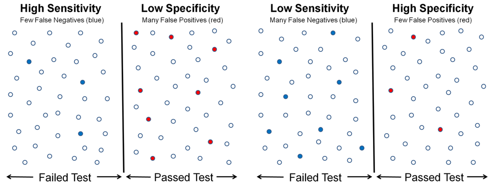

Sensitivity and specificity. Image courtesy of [Wikipedia](https://en.wikipedia.org/wiki/Sensitivity_and_specificity).

## 2.6 Positive/Negative Predictive Value

The Positive Predictive Value (PPV) is the probability that the outcome is really positive given a positive prediction. The Negative Predictive Value (NPV) is the probability that the outcome is really negative given a negative prediction.

It should be apparent that PPV is the same as Precision.

## 2.7 F Measure

The $F$ measure is a weighted combination of other error metrics.

$$F_\beta = (1 + \beta^2) \frac{\text{sensitivity} \cdot \text{precision}}{\text{sensitivity} + \beta^2 \cdot \text{precision}}.$$

The relative importance of the constituent metrics is determined by the $\beta$ coefficient. $\beta$ is often set to 1, in which case one refers to the $F_1$ measure, which is simply the harmonic mean of sensitivity and precision.

$$F_1 = 2 \frac{\text{sensitivity} \cdot \text{precision}}{\text{sensitivity} + \text{precision}}.$$

$F_1$ varies from 0 to 1, where 1 is a perfect classifier (complete sensitivity and precision).

## 2.8 ROC and AUC

The Receiver Operating Characteristics ([ROC](https://en.wikipedia.org/wiki/Receiver_operating_characteristic)) curve is one of the most popular ways of assessing model performance. The ROC curve reflects the change in True Positive Rate (TPR) versus False Positive Rate (FPR) as the classification threshold is varied.

```r
library(ROCR)

myopia.prediction <- prediction(predict(myopia.glm, newdata = myopia.test, type = "prob")[, "Yes"],
                                myopia.test$myopic)
#
# Note that prediction() requires probabilities rather than the predicted classes.
#
plot(performance(myopia.prediction, measure = "tpr", x.measure = "fpr"))
abline(a = 0, b = 1)
```

[figure not shown]

The threshold is 1 in the bottom left of the plot and decreases towards 0 in the top right. Varying the threshold results in different levels of sensitivity and specificity. When the threshold is close to 1 the classifier is conservative, only labelling a case as positive if the probability is high. As a result there are fewer false positives (but it will also miss many positive cases, reducing the number of true positives). A threshold closer to zero will result in more positive predictions, which in turns produces more true positives (but at the same time also more false positives!).

As is evident from the ROC curve above, unless you have a “perfect” classifier, there will always be a tradeoff between TPR and FPR. By varying the value of the threshold you can tune your model either maximise the TPR or minimise the FPR.

```r
performance(myopia.prediction, measure = "auc")@y.values
```

```
[[1]]
[1] 0.9275701
```

AUC varies between 0 and 1, although values below 0.5 should not be achieved in practice. An AUC of 0.5 would be the same as a random guess; values greater than 0.8 indicate a good classifier, while those exceeding 0.9 are excellent.

# 3 Costs of Errors

Consider a model for automated security screening at an airport. The positive class corresponds to a passenger who is carrying a bomb. The occurrence of the positive class is relatively infrequent.

Is it more important to minimise false positives or false negatives?

True positive and true negative results have no cost. A false positive has little cost (the passenger in question would just be manually screened and the error would be rectified). A false negative, on the other hand, would have a massive cost because the threat would not have been detected.

The total cost is

$$C(TP) \cdot TP + C(TN) \cdot TN + C(FP) \cdot FP + C(FN) \cdot FN$$

where

- $C(TP)$ is the cost of a true positive (generally this is zero);
- $C(TN)$ is the cost of a true negative (generally this is zero);
- $C(FP)$ is the cost of a false positive;
- $C(FN)$ is the cost of a false negative.

# 4 Exercises

1. Create a parsimonious model for the `myopia` data. Does its performance differ substantially from the full model?
2. Build a model which predicts the probability of defaulting on credit card debt. Use the `Default` data from the `ISLR` package. Start by trying a simple Linear Regression mode. Satisfy yourself that this is not going to cut the mustard. Now try Logistic Regression.
3. Use the `birthwt` data in the `MASS` package to construct a model for low birth weight. Are there any features which should be excluded from the model?
4. Use the [this data](https://onlinecourses.science.psu.edu/stat501/sites/onlinecourses.science.psu.edu.stat501/files/data/cement.txt) to explore the dangers of multicollinearity in regression. The response y measures the heat evolved in calories during the hardening of cement on a per gram basis. The four predictors are the percentages of four ingredients: tricalcium aluminate (`x1`), tricalcium silicate (`x2`), tetracalcium alumino ferrite (`x3`), and dicalcium silicate (`x4`). Make a linear regression with all predictors and find their variance inflation factors. Is there anything troubling? What would severe multicollinearity mean for interpreting the variables?